# ISLR_chapter07_Moving Beyond Linearity

Big

2019.04.22

## Lab : 비선형모델링(Non-linear Modeling)

> - ISLR 라이브러리에 포함되어있는 Wage 데이터를 사용함

```r
library(ISLR)
```

### 7.8.1 다항식회귀와 계단함수(Polynomial Regression and Step Functions)

```r
fit = lm(wage~poly(age,4), data=Wage)
coef(summary(fit))
```

```
##                 Estimate Std. Error    t value     Pr(>|t|)
## (Intercept)    111.70361  0.7287409 153.283015 0.000000e+00
## poly(age, 4)1  447.06785 39.9147851  11.200558 1.484604e-28
## poly(age, 4)2 -478.31581 39.9147851 -11.983424 2.355831e-32
## poly(age, 4)3  125.52169 39.9147851   3.144742 1.678622e-03
## poly(age, 4)4  -77.91118 39.9147851  -1.951938 5.103865e-02
```

- lm() 함수를 사용하여 선형모델을 적합하는 것으로 age의 4차다항식 poly(age,4)을 사용하여 wage를 예측하는 것이다.
- poly() 함수는 열들이 직교다항식(orthogonal polynomial)들의 기저(basis)인 행렬을 반환하는데, 이것은 본질적으로 각 열이 변수 age, age^2, age^3, age^4의 선형결합임을 의미한다.

```r
fit2 = lm(wage~poly(age,4,raw=TRUE), data=Wage)
coef(summary(fit2))
```

```
##                                Estimate   Std. Error   t value
## (Intercept)               -1.841542e+02 6.004038e+01 -3.067172
## poly(age, 4, raw = TRUE)1  2.124552e+01 5.886748e+00  3.609042
## poly(age, 4, raw = TRUE)2 -5.638593e-01 2.061083e-01 -2.735743
## poly(age, 4, raw = TRUE)3  6.810688e-03 3.065931e-03  2.221409
## poly(age, 4, raw = TRUE)4 -3.203830e-05 1.641359e-05 -1.951938
##                               Pr(>|t|)
## (Intercept)               0.0021802539
## poly(age, 4, raw = TRUE)1 0.0003123618
## poly(age, 4, raw = TRUE)2 0.0062606446
## poly(age, 4, raw = TRUE)3 0.0263977518
## poly(age, 4, raw = TRUE)4 0.0510386498
```

- poly()에 raw=TRUE 옵션을 사용하여 age, age^2, age^3, age^4을 직접 얻을 수도 있다.
- 나중에 보겠지만 이렇게 해도 모델에 별 영향은 없다.(basis의 선택은 명백히 계수 추정치에 영향은 주지만 적합된 값에 영향을 주지는 않는다.)

```r
fit2a = lm(wage~age+I(age^2)+I(age^3)+I(age^4), data=Wage)
coef(fit2a)
```

```
##   (Intercept)           age      I(age^2)      I(age^3)      I(age^4)
## -1.841542e+02  2.124552e+01 -5.638593e-01  6.810688e-03 -3.203830e-05
```

- R에서는 몇가지 다른 방식으로도 위 모델을 적합할 수 있다.
- 이것은 단순히 다항식 basis 함수를 즉석해서 생성하는 것으로, 래퍼(wrapper)함수 I()를 통해 age^2와 같은 항을 처리한다.(식에서 ^ 기호는 특별한 의미를 가진다.)

```r
fit2b = lm(wage~cbind(age, age^2, age^3, age^4), data=Wage)
coef(fit2b)
```

```
##                        (Intercept) cbind(age, age^2, age^3, age^4)age
##                      -1.841542e+02                       2.124552e+01
##    cbind(age, age^2, age^3, age^4)    cbind(age, age^2, age^3, age^4)
##                      -5.638593e-01                       6.810688e-03
##    cbind(age, age^2, age^3, age^4)
##                      -3.203830e-05
```

- cbind를 사용할수도있다.

```r
agelims = range(Wage$age)
age.grid = seq(from=agelims[1], to=agelims[2])
preds = predict(fit, newdata=list(age=age.grid), se=TRUE)
se.bands = cbind(preds$fit + 2 * preds$fit, preds$fit - 2 * preds$se.fit)
```

- 이제 예측값을 원하는 age의 각 값을 생성하고, 그 다음에 표준오차도 제공하도록 명시하여 predict() 함수를 호출한다.

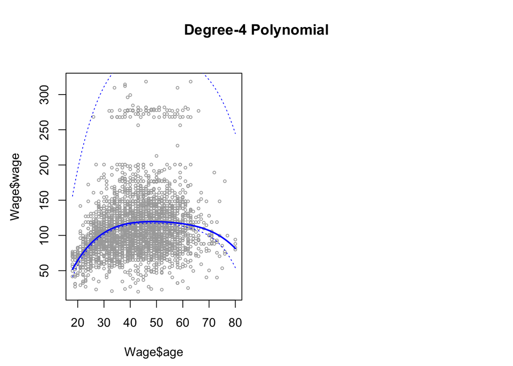

```r
par(mfrow=c(1,2), mar=c(4.5, 4.5, 1, 1), oma=c(0, 0, 4, 0))
plot(Wage$age,Wage$wage,xlim=agelims, cex=0.5, col="darkgrey")
title("Degree-4 Polynomial", outer=T)
lines(age.grid, preds$fit, lwd=2, col="blue")
matlines(age.grid, se.bands, lwd=1, col="blue", lty=3)
```

* 마지막으로, 데이터를 그래프로 나타내고 4차 다항식 적합을 추가한다.

```r
preds2 = predict(fit2, newdata = list(age=age.grid), se=TRUE)
max(abs(preds$fit-preds2$fit))
```

```
## [1] 7.81597e-11
```

- 앞에서 언급했듯이, basis 함수들의 직교집합이 poly() 함수에서 생성된 것인지의 여부는 모델에 별 영향을 미치지 않을 것이다.
- 이것은 얻어진 적합 값이 동일하다는 것을 의미한다.
> - 다항식회귀를 수행할 때는 사용할 다항식의 차수를 결정해야 하며, 한가지 방법은 가설검정을 사용하는 것이다.
> - 이제, 선형에서 5차 다항식까지의 모델을 적합하고 wage와 age의 상관관계를 설명하는데 충분한 가장 간단한 모델을 결정하고자 한다.
> - 분산분석(ANOVA, F-검정을 사용)을 수행하는 anova() 함수를 사용하여 모델 M_1 이 데이터를 설명하는데 충분하다는 귀무가설을 좀 더 복잡한 모델 M_2 가 필요하다는 대립가설에 대해 검정한다.
> - anova() 함수를 사용하기 위해서는 M_1 과 M_2 가 내포(nested) 모델이어야 한다.
> - 즉, M_1 설명변수들은 M_2의 설명변수들의 subset 이어야 한다.
> - 이 예의 경우, 5가지 다른 모델을 적합하여 순차적으로 단순한 모델을 좀 더 복잡한 모델과 비교한다.

```r
fit.1 = lm(wage~age, data=Wage)
fit.2 = lm(wage~poly(age,2), data=Wage)
fit.3 = lm(wage~poly(age,3), data=Wage)
fit.4 = lm(wage~poly(age,4), data=Wage)
fit.5 = lm(wage~poly(age,5), data=Wage)
anova(fit.1, fit.2, fit.3, fit.4, fit.5)
```

```
## Analysis of Variance Table
##
## Model 1: wage ~ age
## Model 2: wage ~ poly(age, 2)
## Model 3: wage ~ poly(age, 3)
## Model 4: wage ~ poly(age, 4)
## Model 5: wage ~ poly(age, 5)
##   Res.Df     RSS Df Sum of Sq        F    Pr(>F)
## 1   2998 5022216
## 2   2997 4793430  1    228786 143.5931 < 2.2e-16 ***
## 3   2996 4777674  1     15756   9.8888  0.001679 **
## 4   2995 4771604  1      6070   3.8098  0.051046 .
## 5   2994 4770322  1      1283   0.8050  0.369682
## ---
## Signif. codes:  0 '***' 0.001 '**' 0.01 '*' 0.05 '.' 0.1 ' ' 1
```

```r
coef(summary(fit.5))
```

```
##                 Estimate Std. Error     t value     Pr(>|t|)
## (Intercept)    111.70361  0.7287647 153.2780243 0.000000e+00
## poly(age, 5)1  447.06785 39.9160847  11.2001930 1.491111e-28
## poly(age, 5)2 -478.31581 39.9160847 -11.9830341 2.367734e-32
## poly(age, 5)3  125.52169 39.9160847   3.1446392 1.679213e-03
## poly(age, 5)4  -77.91118 39.9160847  -1.9518743 5.104623e-02
## poly(age, 5)5  -35.81289 39.9160847  -0.8972045 3.696820e-01
```

```r
(-11.9830341)^2
```

```
## [1] 143.5931
```

- anova() 함수를 사용하는 대신에 poly()가 직교 다항식들을 생성한다는 사실을 이용하면 더 간결하게 p-value을 얻을 수 있다.
- 결과를 보면 p-value는 동일하고 t-통계량의 제곱은 anova() 함수의 F-통계량과 같다는 것을 알 수 있다.

```r
fit.1 = lm(wage~education+age, data=Wage)
fit.2 = lm(wage~education+poly(age,2), data=Wage)
fit.3 = lm(wage~education+poly(age,3), data=Wage)
anova(fit.1,fit.2,fit.3)
```

```
## Analysis of Variance Table
##
## Model 1: wage ~ education + age
## Model 2: wage ~ education + poly(age, 2)
## Model 3: wage ~ education + poly(age, 3)
##   Res.Df     RSS Df Sum of Sq        F Pr(>F)
## 1   2994 3867992
## 2   2993 3725395  1    142597 114.6969 <2e-16 ***
## 3   2992 3719809  1      5587   4.4936 0.0341 *
## ---
## Signif. codes:  0 '***' 0.001 '**' 0.01 '*' 0.05 '.' 0.1 ' ' 1
```

- 하지만, ANOVA 방법은 직교 다항식의 사용여부와 상관없이 동작한다.
- 이 방법은 모델에 다른항이 있을 때에도 동작한다.
- 예를 들어, anova()를 사용하여 다음처럼 세 모델을 비교할 수 있다.
> - 다음으로, 개인의 연간 소득이 25만 달러보다 더 높은지 예측하는 것을 생각해보자.
> - 진행 방식은 앞에서와 같으며, 다른 점은 적절한 반응변수 벡터를 먼저 생성한 다음에 family=“binomial” 옵션으로 glm()함수를 적용하여 다항식 로지스틱 회귀모델을 적합한다는 것이다.

```r
fit = glm(I(wage>250)~poly(age,4), data=Wage, family=binomial)
```

- 반응변수를 즉석해서 생성하기위해 I()를 사용한다.
- 표현식 wage > 250은 TRUE와 FALSE를 포함하는 논리변수로 평가되는데, glm()은 TRUE는 1로 FALSE는 0으로 설정하여 이진수로 변환한다.

```r
preds = predict(fit, newdata=list(age=age.grid), se=T)
```

- 다시 predict()로 예측

```r
pfit = exp(preds$fit) / (1-exp(preds$fit))
se.bands.logit = cbind(preds$fit+2*preds$se.fit, preds$fit-2*preds$se.fit)
se.bands = exp(se.bands.logit) / (1-exp(se.bands.logit))
```

- 신뢰구간을 계산하는 것은 선형회귀의 경우보다 더 복잡하다.
- glm() 모델은 기본적인 예측 유형은 type=“link”이며, 여기서도 같은 유형을 사용한다.

```r
preds = predict(fit, newdata=list(age=age.grid), type="response", se=T)
```

- predict() 함수에서 type=“response” 옵션을 사용하면 확률을 직접 구할 수 있다.

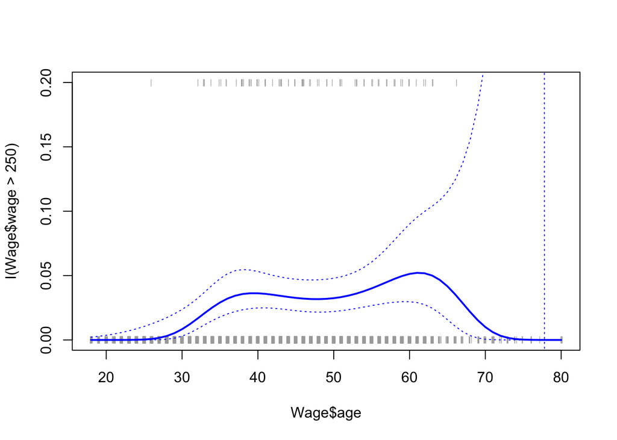

```r
plot(Wage$age, I(Wage$wage>250), xlim=agelims, type="n", ylim=c(0,0.2))
points(jitter(Wage$age), I((Wage$wage>250)/5), cex=0.5, pch="|", col="darkgrey")
lines(age.grid, pfit, lwd=2, col="blue")
matlines(age.grid, se.bands, lwd=1, col="blue", lty=3)
```

* wage 값이 250보다 큰 관측치에 대응하는 age 값은 그래프의 윗 부분에 회색으로 표시하고, 250보다 작은 wage 값을 갖는 관측치의 age 값은 그래프의 아랫부분에 회색으로 표시하였다. * 같은 age 값을 가진 관측치들이 서로 겹치지 않도록 jitter() 함수를 사용하여 age 값을 변환시켰다. * 이러한 그래프를 보통 rug 그래프라고 한다.

```r
table(cut(Wage$age,4))
```

```
##
## (17.9,33.5]   (33.5,49]   (49,64.5] (64.5,80.1]
##         750        1399         779          72
```

```r
fit = lm(wage~cut(age,4), data=Wage)
coef(summary(fit))
```

```
##                         Estimate Std. Error   t value     Pr(>|t|)
## (Intercept)            94.158392   1.476069 63.789970 0.000000e+00
## cut(age, 4)(33.5,49]   24.053491   1.829431 13.148074 1.982315e-38
## cut(age, 4)(49,64.5]   23.664559   2.067958 11.443444 1.040750e-29
## cut(age, 4)(64.5,80.1]  7.640592   4.987424  1.531972 1.256350e-01
```

### 7.8.2 스플라인(Splines)

> - 회귀 스플라인을 적합하기 위해서는 splines 라이브러리를 사용한다.
> - 7.4절에서 보았듯이 basis함수들의 적절한 행렬을 구성함으로써 회귀 스플라인을 적합할 수 있다.
> - bs() 함수는 지정된 knots(매듭)과 set(집합)을 가진 스플라인들에 대한 basis함수들의 전체 행렬을 생성한다.
> - 기본적으로는 삼차 스플라인이 생성된다.

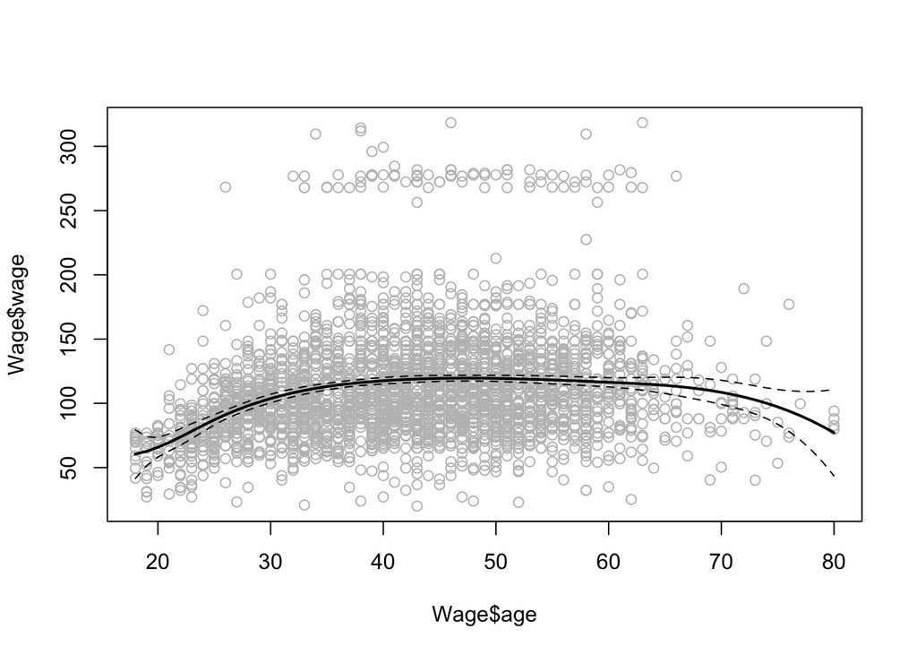

```r
library(splines)
fit = lm(wage~bs(age, knots=c(25,40,60)), data=Wage)
pred = predict(fit, newdata=list(age = age.grid), se=T)
plot(Wage$age,Wage$wage,col="gray")
lines(age.grid, pred$fit, lwd=2)
lines(age.grid, pred$fit + 2 * pred$se, lty="dashed")
lines(age.grid, pred$fit - 2 * pred$se, lty="dashed")
```

* 지정된 knots는 25, 40, 60 이다. * 이것은 6개의 basis함수를 가진 스플라인을 제공한다.(3개의 knots를 가진 삼차스플라인은 자유도가 7이며, 자유도 7은 절편과 6개의 basis함수에 의한 것이다.)

```r
dim(bs(Wage$age,knots=c(25,40,60)))
```

```
## [1] 3000    6
```

```r
dim(bs(Wage$age,df=6))
```

```
## [1] 3000    6
```

```r
attr(bs(Wage$age,df=6), "knots")
```

```
##   25%   50%   75%
## 33.75 42.00 51.00
```

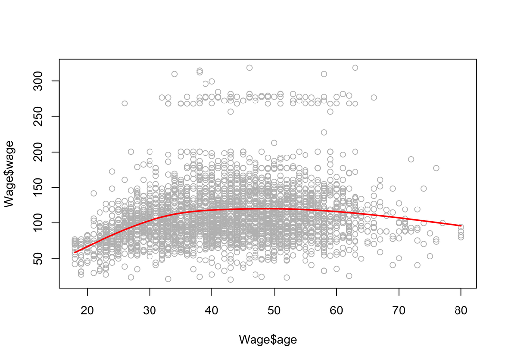

```r
fit2 = lm(wage~ns(age, df=4), data=Wage)
pred2 = predict(fit2, newdata = list(age=age.grid), se=T)
plot(Wage$age,Wage$wage,col="gray")
lines(age.grid, pred2$fit, col="red", lwd = 2)
```

* 자연 스플라인(natural spline)을 적합하기 위해서는 ns() 함수를 사용한다. * 자유도가 4인 자연스플라인을 적합한다.

```r
plot(Wage$age, Wage$wage, xlim=agelims, cex=0.5, col="darkgrey")
title("Smoothing Spline")
fit=smooth.spline(Wage$age, Wage$wage, df=16)
fit2=smooth.spline(Wage$age, Wage$wage, cv=TRUE)
fit2$df
```

```
## [1] 6.794596
```

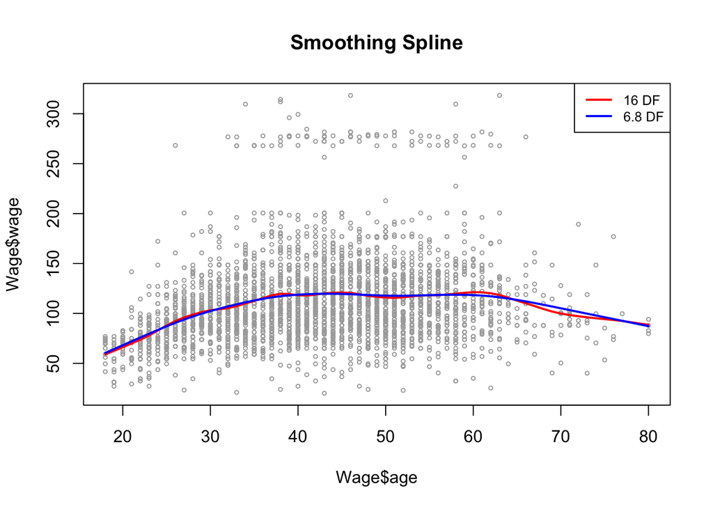

```r
lines(fit, col="red", lwd=2)
lines(fit2, col="blue", lwd=2)
legend("topright", legend=c("16 DF", "6.8 DF"), col=c("red","blue"), lty=1, lwd=2, cex=0.8)
```

* 평활 스플라인을 적합하기 위해서는 smooth.spline() 함수를 사용한다. * smooth.spline()에 대한 첫 번째 호출에서 df=16으로 지정하였다. 그러면 함수는 자유도가 16이 되는 람다 값을 결정한다. * 두 번째 smooth.spline() 호출에서는 교차검증에 의해 평활도 수준을 선택한다. 이 결과로 자유도가 6.8이 되는 람다값을 선택한다.

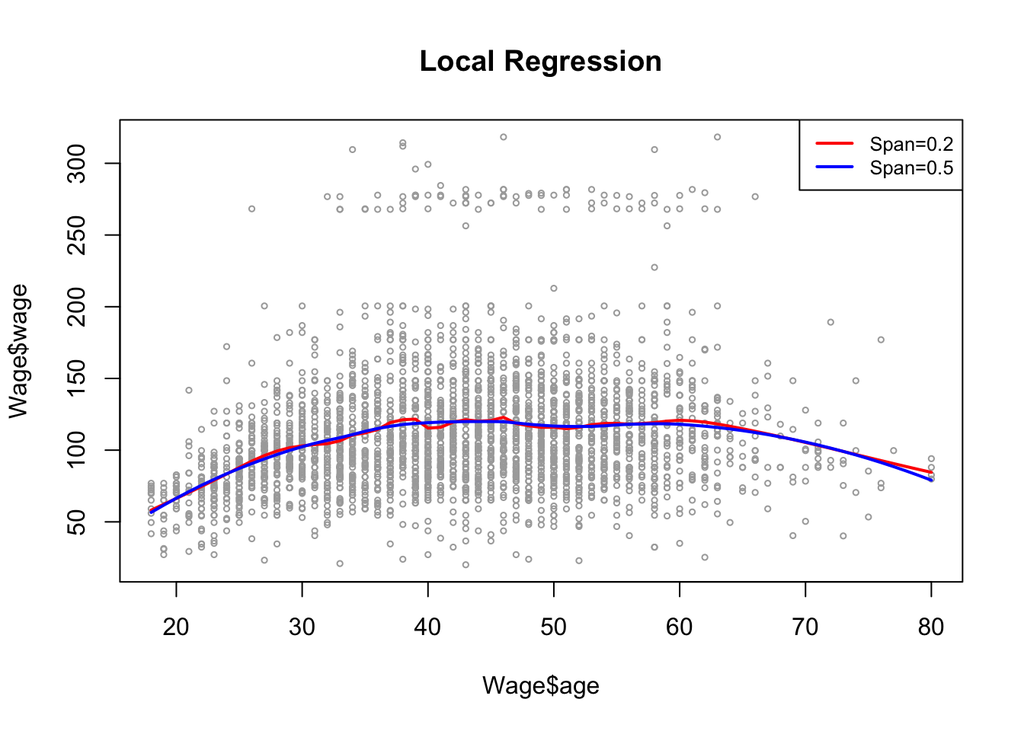

```r
plot(Wage$age, Wage$wage, xlim=agelims, cex=0.5, col="darkgrey")
title("Local Regression")
fit = loess(wage~age, span=0.2, data=Wage)
fit2 = loess(wage~age, span=0.5, data=Wage)
lines(age.grid, predict(fit, data.frame(age=age.grid)), col="red", lwd=2)
lines(age.grid, predict(fit2, data.frame(age=age.grid)), col="blue", lwd=2)
legend("topright", legend=c("Span=0.2","Span=0.5"), col=c("red","blue"), lty=1, lwd=2, cex=0.8)
```

* local regression(국소회귀)를 수행하기 위해서는 loess() 함수를 사용한다. * span이 0.2와 0.5인 local regression을 수행하였다. * 즉, 각 이웃은 관측치들의 20% 또는 50%로 구성된다. span이 클수록 적합이 더 평활하다. * locfit 라이브러리도 국소회귀모델을 적합하기 위해 사용될 수 있다.

### 7.8.3 GAMs

```r
gam1 = lm(wage~ns(year,4) + ns(age,5) + education, data=Wage)
```

- year과 age의 자연 스플라인 함수를 사용하여 wage를 예측하도록 GAM을 반환한다.
- 변수 education은 (식 7.16)에서와 같이 질적 설명변수로 취급한다.
- GAM은 적절히 선택된 basis함수를 사용하는 큰 선형회귀모델이므로 lm()함수를 사용하여 적합한다.
> - 평활 스플라인을 사용하여 모델(식 7.16)을 적합한다.
> - 평활 스플라인 또는 basis함수들로 표현될 수 없는 다른 성분들을 사용하여 좀 더 일반적인 종류의 GAMs을 적합하고 최소제곱을 사용하여 적합하려면 gam 라이브러리를 사용해야 한다.

```r
library(gam)
gam.m3 = gam(wage~s(year,4) + s(age,5) + education, data=Wage)
```

- gam 라이브러리의 s() 함수는 평활 스플라인을 사용할때 나타낸다.
- year의 함수는 자유도가 4, age의 함수는 자유도를 5라고 지정한다.
- education은 질적변수이므로 그대로 두는데 4개의 가변수로 변환된다.
- gam() 함수를 사용하여 GAM을 적합한다.
- (식 7.16)의 모든 항들은 동시에 적합되며 서로를 고려하여 반응변수를 설명한다.

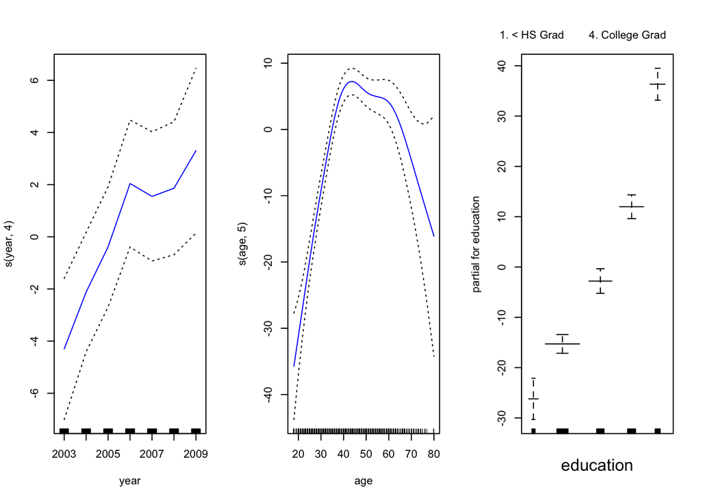

```r
par(mfrow=c(1,3))
plot(gam.m3, se=TRUE, col="blue")
```

* (그림 7.12)의 그래프는 단순하게 plot() 함수를 호출하면 만들어진다.

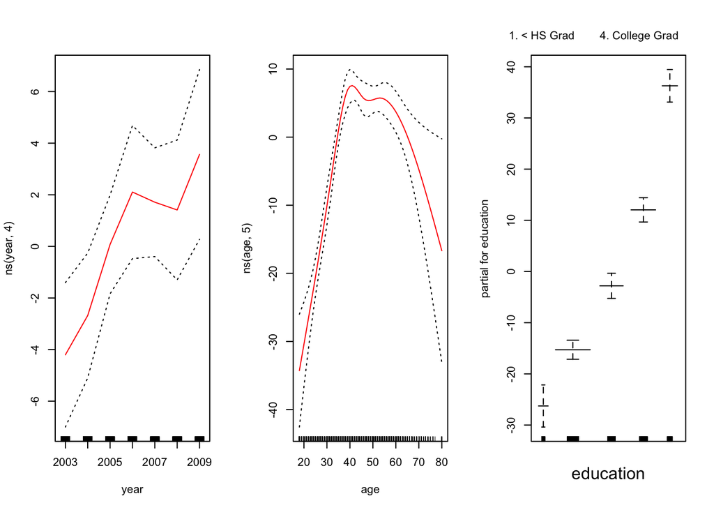

```r
par(mfrow=c(1,3))
plot.Gam(gam1, se=TRUE, col="red")
```

* 일반 plot() 함수는 gam.m3가 gam 클래스의 객체라는 것을 인지하고 적절한 plot.gam() 멤버함수를 호출한다. * gam1은 gam 클래스가 아니라 lm 클래스의 객체이지만 여전히 plot.gam()을 사용할 수 있다.

```r
gam.m1 = gam(wage~s(age,5) + education, data=Wage)
gam.m2 = gam(wage~year + s(age,5) + education, data=Wage)
anova(gam.m1, gam.m2, gam.m3, test="F")
```

```
## Analysis of Deviance Table
##
## Model 1: wage ~ s(age, 5) + education
## Model 2: wage ~ year + s(age, 5) + education
## Model 3: wage ~ s(year, 4) + s(age, 5) + education
##   Resid. Df Resid. Dev Df Deviance       F    Pr(>F)
## 1      2990    3711731
## 2      2989    3693842  1  17889.2 14.4771 0.0001447 ***
## 3      2986    3689770  3   4071.1  1.0982 0.3485661
## ---
## Signif. codes:  0 '***' 0.001 '**' 0.01 '*' 0.05 '.' 0.1 ' ' 1
```

- 그래프에서 year의 함수는 다소 선형적으로 보인다.
- ANOVA 검정을 수행하여 세 모델, 즉 year를 제외한 GAM(M_1), year의 선형함수를 사용한 GAM(M_2), 또는 year의 스플라인 함수를 사용한 GAM(M_3) 중 어느것이 최고인지 결정할 수 있다.
- 결과를 보면, year의 선형함수를 가진 GAM이 year를 전혀 포함하지 않는 GAM보다 더 낫다는 믿을만한 증거가 있다.(p-value=0.0001447)
- 하지만, year의 비선형 함수가 필요하다는 증거는 없다.(p-value=0.3485661)
- 다시말하면, ANOVA 결과에 따르면 M_2(Model 2)가 선호하는 모델이다.

```r
summary(gam.m3)
```

```
##
## Call: gam(formula = wage ~ s(year, 4) + s(age, 5) + education, data = Wage)
## Deviance Residuals:
##     Min      1Q  Median      3Q     Max
## -119.43  -19.70   -3.33   14.17  213.48
##
## (Dispersion Parameter for gaussian family taken to be 1235.69)
##
##     Null Deviance: 5222086 on 2999 degrees of freedom
## Residual Deviance: 3689770 on 2986 degrees of freedom
## AIC: 29887.75
##
## Number of Local Scoring Iterations: 2
##
## Anova for Parametric Effects
##              Df  Sum Sq Mean Sq F value    Pr(>F)
## s(year, 4)    1   27162   27162  21.981 2.877e-06 ***
## s(age, 5)     1  195338  195338 158.081 < 2.2e-16 ***
## education     4 1069726  267432 216.423 < 2.2e-16 ***
## Residuals  2986 3689770    1236
## ---
## Signif. codes:  0 '***' 0.001 '**' 0.01 '*' 0.05 '.' 0.1 ' ' 1
##
## Anova for Nonparametric Effects
##             Npar Df Npar F  Pr(F)
## (Intercept)
## s(year, 4)        3  1.086 0.3537
## s(age, 5)         4 32.380 <2e-16 ***
## education
## ---
## Signif. codes:  0 '***' 0.001 '**' 0.01 '*' 0.05 '.' 0.1 ' ' 1
```

- summary() 함수는 gam 적합의 요약을 보여준다.
- 위 결과에서 year와 age에 대한 p-value는 선형 상관관계의 귀무가설과 비선형 상관관계의 대립가설에 대응한다.
- year에 대한 큰 p-value은 선형함수이면 충분하다는 ANOVA 검정에서 얻은 결론을 뒷받침해준다.(책에서는 year의 p-value = 0.35 로 되어있어 이런 결론을 낼 수 있음)
- 하지만 age에 대해서는 비선형 항이 필요하다는 명백한 증거를 보여준다.

```r
preds = predict(gam.m2, newdata = Wage) # 훈련셋 예측
```

- predict() 함수를 사용하여 gam 객체를 예측할 수 있다.

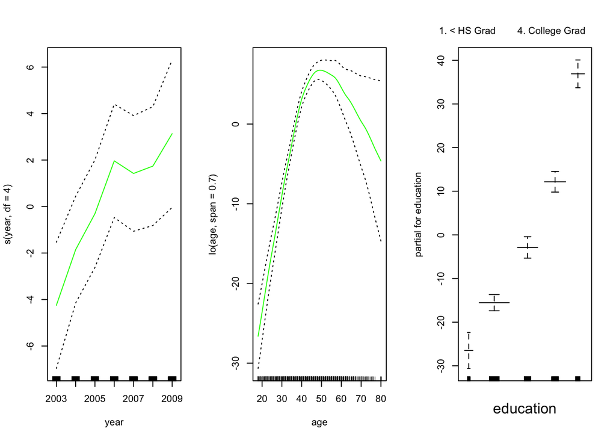

```r
par(mfrow=c(1,3))
gam.lo = gam(wage~s(year, df=4) + lo(age, span=0.7) + education, data = Wage)
plot.Gam(gam.lo, se = TRUE, col="green")
```

* lo() 함수를 이용한 local regression을 GAM의 구성요소로 사용할 수 있다. * age 항에 대해 span=0.7 인 local regression을 사용하였다.

```r
gam.lo.i = gam(wage~lo(year, age, span=0.5) + education, data = Wage)
```

- 또한, lo() 함수를 사용하여 gam() 함수를 호출하기 전에 상호작용 항들을 만들수 있다.
- 예를 들어, 다음은 항이 2개인 모델을 적합하는 것으로, 첫 번째 항은 year과 age의 상호작용 항이고 국소회귀에 의해 적합된다.

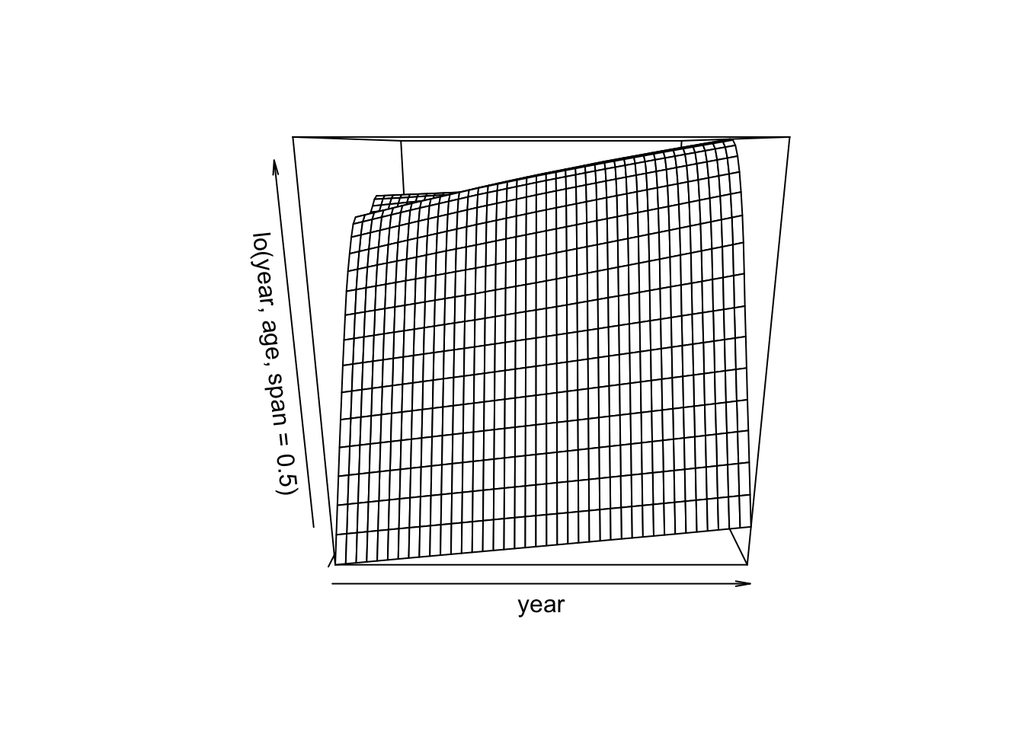

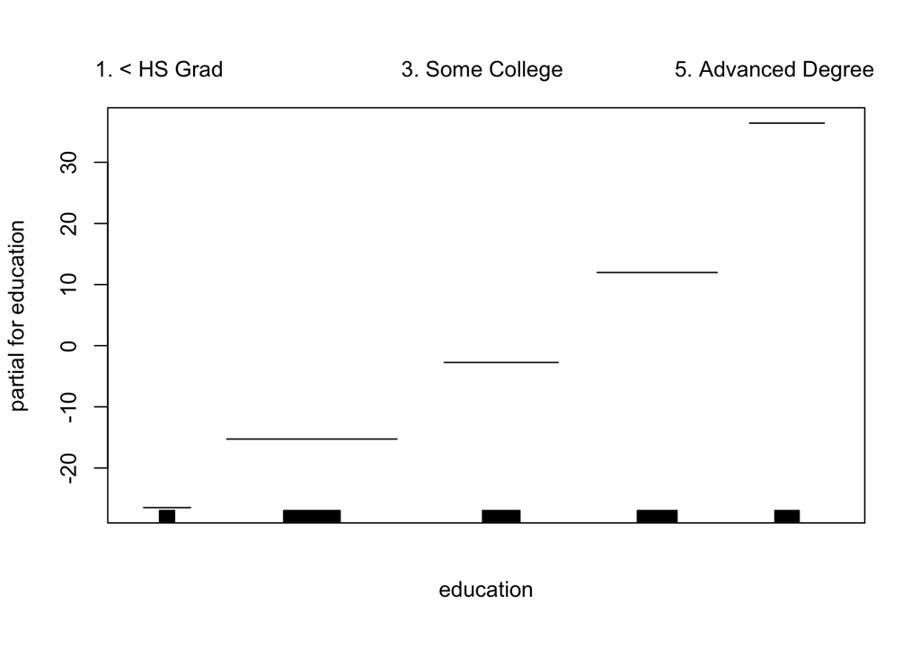

```r
library(akima)
plot(gam.lo.i)
```

* akima 패키지를 사용하면 결과인 2차원 표면을 그래프로 나타낼 수 있다.

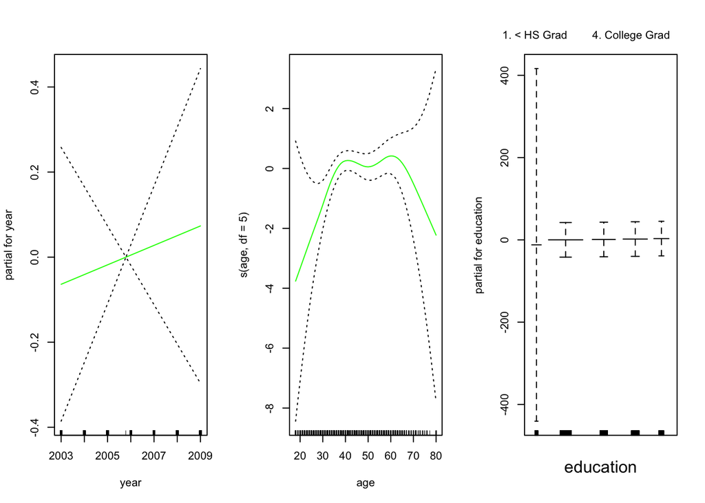

```r
gam.lr = gam(I(wage>250)~year+s(age,df=5)+education, family=binomial, data=Wage)
par(mfrow=c(1,3))
plot(gam.lr, se=T, col="green")
```

* 로지스틱 회귀 GAM을 적합하기 위해서는 이진 반응변수를 구성하는데 I() 함수를 사용하고 family=“binomial”로 설정한다.

```r
table(Wage$education, I(Wage$wage>250))
```

```
##
##                      FALSE TRUE
##   1. < HS Grad         268    0
##   2. HS Grad           966    5
##   3. Some College      643    7
##   4. College Grad      663   22
##   5. Advanced Degree   381   45
```

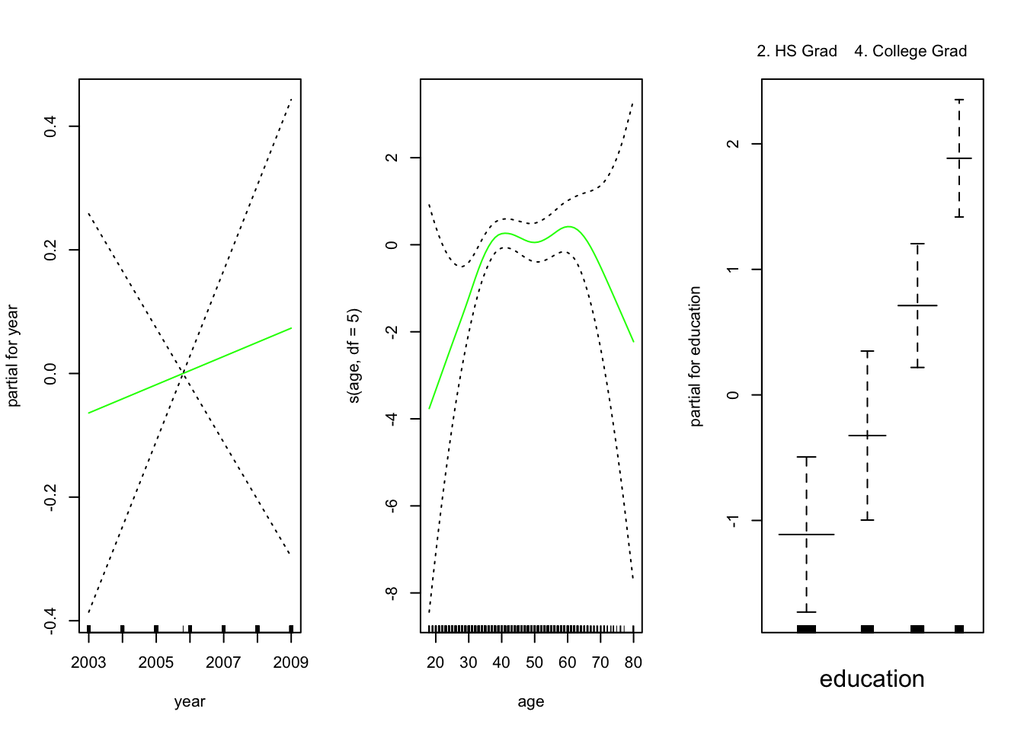

```r
gam.lr.s = gam(I(wage>250)~year+s(age,df=5)+education, family=binomial, data=Wage, subset=(education != "1. < HS Grad"))
par(mfrow=c(1,3))
plot(gam.lr.s, se=T, col="green")
```

* 결과를 보면 <HS 범주에는 소득이 높은 사람이 없다는 것을 알 수 있다. * 따라서 <HS를 제외한 모든 범주를 사용하여 로지스틱 회귀 GAM를 적합한다. * 이것은 좀 더 합리적인 결과를 제공한다.